# Solution of TDSE for a free gaussian wavepacket using FTCS Explicit Method

Implementing tridiagonal matrix method to evaluate solution (with dead wall boundary condition) This can also be solved using traditional array construction as of 1D diffusion equation

```
>psi[x][t+1]=psi[x][t]+0.5*(i*dt/dx**2)*(psi[x+1][t]-2psi[x][t]+psi[x-1][t])-i*V[x][t]*dt*psi[x][t]

>psi[x][t+1]=mu*psi[x+1][t]+(1-2*mu-i*dt*V[x][t])*psi[x][t]+mu*psi[x-1][t]

>where mu=0.5*i*dt/dx**2
```

This simple minded algorithm is not a good algorithm as norm is not preserved for approximation and the solution diverges for very small dt (norm increases)

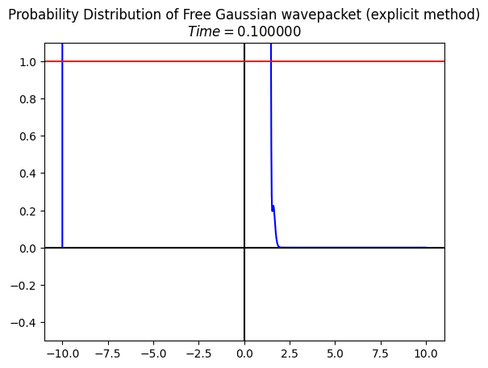

```python
import numpy as np
import matplotlib.pyplot as plt

#Constants
a=1.0         #standard deviation of gaussian
x0=-5.0       #mean of gaussian
k=20.0        #wave-vector

#Parameters
L=20.0        #length of the box
N=1000        #Discretized spatial points
dt=0.00005    #Time step (Neumann Stability Condition)
t=0           #Initial time
tf=0.1        #Final time

#Initial condition
xs,dx=np.linspace(-L/2,L/2,N,retstep=True)
us=np.exp(-(xs-x0)**2/a+(0.0+1.j)*k*xs)    #This is same as the 1st column (initial time) of 2D array used in 1D diffusion equation. This 1D array will be updated with time
mu=dt/dx**2*(0.+1.j)/2

#Applied potential
Vs=0*xs[1:-1]    #Only taking inside points which will be updated by M matrix.

#Explicit Algorithm to create tridiagonal matrix M
M=np.eye(N-2)*(1-2*mu)-np.diag(1.j*dt*Vs)+mu*np.eye(N-2,k=1)+mu*np.eye(N-2,k=-1)      #np.eye() creates identity matrix. k parameter shifts the leading diagonal to submajor or subminor position. np.diag() creates a diagonal matrix with elements of Vs array

while t<tf:
    us[1:-1]=np.dot(M,us[1:-1])            #Solution matrix generated over space in a given time slice (except end points) which is being updated with next time slices
    t+=dt

#Plotting
plt.plot(xs,np.abs(us)**2,color='blue')
plt.title(r'Probability Distribution of Free Gaussian wavepacket (explicit method)'+'\n$Time = %10.6f$'%(t-dt))
plt.axvline(x=0,color='black')
plt.axhline(y=0,color='black')
plt.axhline(y=1,color="red")
plt.ylim(-0.5,1.1)
plt.show()
```

# Solution of TDSE for a free gaussian wavepacket using FTCS Implicit Method

Implementing tridiagonal matrix method to evaluate solution (with dead wall boundary condition)

```
>psi[x][t+1]=psi[x][t]+0.5*(i*dt/dx**2)*(psi[x+1][t+1]-2psi[x][t+1]+psi[x-1][t+1])-i*V[x][t+1]*dt*psi[x][t+1]

>psi[x][t]=-mu*psi[x+1][t+1]+(1+2*mu+i*dt*V[x][t+1])*psi[x][t+1]-mu*psi[x-1][t+1]

>where mu=0.5*i*dt/dx**2
```

Norm is not preserved for approximation (norm decreases)

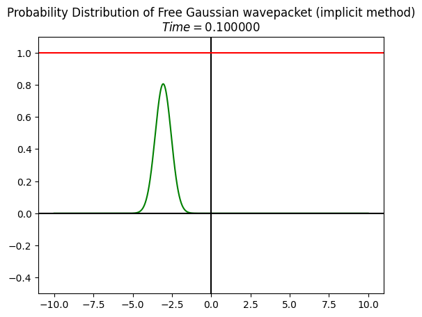

```python
import numpy as np
import matplotlib.pyplot as plt

#Constants
a=1.0         #standard deviation of gaussian
x0=-5.0       #mean of gaussian
k=20.0        #wave-vector

#Parameters
L=20.0        #length of the box
N=1000        #Discretized spatial points
dt=0.00005    #Time step (Neumann Stability Condition)
t=0           #Initial time
tf=0.1        #Final time

#Initial condition
xs,dx=np.linspace(-L/2,L/2,N,retstep=True)
us=np.exp(-(xs-x0)**2/a+(0.0+1.j)*k*xs)    #This is same as the 1st column (initial time) of 2D array used in 1D diffusion equation. This 1D array will be updated with time
mu=dt/dx**2*(0.+1.j)/2

#Applied potential
Vs=0*xs[1:-1]    #Only taking inside points which will be updated by M matrix.

#Explicit Algorithm to create tridiagonal matrix M
M=np.eye(N-2)*(1+2*mu)+np.diag(1.j*dt*Vs)-mu*np.eye(N-2,k=1)-mu*np.eye(N-2,k=-1)      #np.eye() creates identity matrix. k parameter shifts the leading diagonal to submajor or subminor position. np.diag() creates a diagonal matrix with elements of Vs array
M=np.linalg.inv(M)

while t<tf:
    us[1:-1]=np.dot(M,us[1:-1])            #Solution matrix generated over space in a given time slice (except end points) which is being updated with next time slices
    t+=dt

#Plotting
plt.plot(xs,np.abs(us)**2,color='green')
plt.title(r'Probability Distribution of Free Gaussian wavepacket (implicit method)'+'\n$Time = %10.6f$'%(t-dt))
plt.axvline(x=0,color='black')
plt.axhline(y=0,color='black')
plt.axhline(y=1,color="red")
plt.ylim(-0.5,1.1)
plt.show()
```

# Solution of TDSE for a free gaussian wavepacket using FTCS Crank Nicolson Method

Taking average of 2nd order in space of both implicit and explicit method to preserve norm

```
>psi[x][t+1]=psi[x][t]+0.5*(i*dt/dx**2)*(psi[x+1][t]-2psi[x][t]+psi[x-1][t])-i*V[x][t]*dt*psi[x][t]

>psi[x][t+1]=mu*psi[x+1][t]+(1-2*mu-i*dt*V[x][t])*psi[x][t]+mu*psi[x-1][t]

>where mu=0.5*i*dt/dx**2
```

This algorithm preserves stability, accuracy and unitarity

```
The initial norm of the wavefunction is : 1.0000000000000002
```

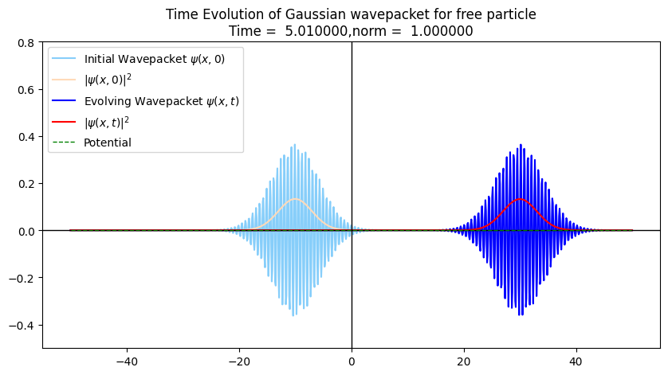

```
The final norm of the wavefunction is : 1.000000000003335
The Norm is preserved
```

```python
import numpy as np
import matplotlib.pyplot as plt
from scipy.integrate import simpson

#Constants
sigma=3         #standard deviation of gaussian
x0=-10.0        #mean of gaussian
k=10.0          #wave-vector

#Parameters
L=100           #length of the box
N=1000          #Discretized spatial points
dt=0.01         #Time step (Neumann Stability Condition)
t=0             #Initial time
tf=5            #Final time

#Initial condition
xs,dx=np.linspace(-L/2,L/2,N,retstep=True)
mu=dt/dx**2*(0.+1.j)/2

a=(np.sqrt(2*np.pi*sigma**2))
us=1/(np.sqrt(a))*np.exp(-(xs-x0)**2/(4*sigma**2)+1j*k*xs)    #This is same as the 1st column (initial time) of 2D array used in 1D diffusion equation. This 1D array will be updated with time

Norm_initial=simpson(np.abs(us)**2,x=xs)
print('The initial norm of the wavefunction is :',Norm_initial)

#Applied potential
Vs=0*xs[1:-1]    #Only taking inside points which will be updated by M matrix.

#Seting Matrix
A1=np.eye(N-2)*(1-mu)+np.diag(-1.j*dt/2*Vs)+mu/2*np.eye(N-2,k=1)+mu/2*np.eye(N-2,k=-1)
A2=np.eye(N-2)*(1+mu)+np.diag(1.j*dt/2*Vs)-mu/2*np.eye(N-2,k=1)-mu/2*np.eye(N-2,k=-1)
B=np.dot(np.linalg.inv(A2),A1)

#Time Evolution and Plotting
plt.figure(figsize=(10,5))

plt.plot(xs,us,color='lightskyblue',label=r'Initial Wavepacket $\psi(x,0)$')
plt.plot(xs,np.abs(us)**2,color='peachpuff',label=r'$|\psi(x,0)|^2$')

while t<tf:
    us[1:-1]=np.dot(B,us[1:-1])            #Solution matrix generated over space in a given time slice (except end points) which is being updated with next time slices
    t+=dt

plt.title('Time Evolution of Gaussian wavepacket for free particle\n'+r'Time =%10.6f,norm =%10.6f'%(t,simpson(np.abs(us)**2,x=xs)))

plt.plot(xs,us,color='blue',label=r'Evolving Wavepacket $\psi(x,t)$')
plt.plot(xs,np.abs(us)**2,color='red',label=r'$|\psi(x,t)|^2$')

plt.axvline(x=0,color='black',lw=1)
plt.axhline(y=0,color='black',lw=1)
plt.plot(xs[1:-1],Vs,'--',color='green',lw=1,label='Potential')

plt.ylim(-0.5,0.8)
plt.legend()
plt.show()

#Conservation of norm
Norm_final=simpson(np.abs(us)**2,x=xs)
print('The final norm of the wavefunction is :',Norm_final)

if round(Norm_initial/Norm_final)==1:
    print('The Norm is preserved')
else:
    print('Norm is not preserved')
```

# Solution of TDSE for a ground state wavefunction in harmonic potential using FTCS Crank Nicolson Method

Taking average of 2nd order in space of both implicit and explicit method to preserve norm

```
>psi[x][t+1]=psi[x][t]+0.5*(i*dt/dx**2)*(psi[x+1][t]-2psi[x][t]+psi[x-1][t])-i*V[x][t]*dt*psi[x][t]

>psi[x][t+1]=mu*psi[x+1][t]+(1-2*mu-i*dt*V[x][t])*psi[x][t]+mu*psi[x-1][t]

>where mu=0.5*i*dt/dx**2
```

This algorithm preserves stability, accuracy and unitarity

```
The initial norm of the wavefunction is : 1.0
```

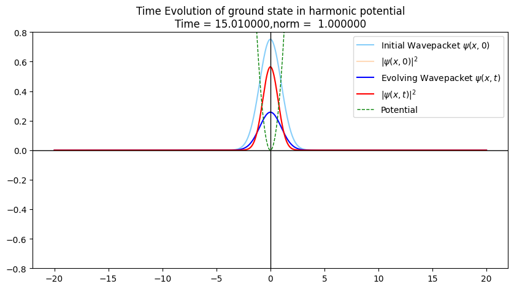

```
The final norm of the wavefunction is : 1.0000000000000648
The Norm is preserved
```

```python
import numpy as np
import matplotlib.pyplot as plt
from scipy.integrate import simpson

#Parameters
L=40            #length of the box
N=1000          #Discretized spatial points
dt=0.01         #Time step (Neumann Stability Condition)
t=0             #Initial time
tf=15           #Final time

#Initial condition
xs,dx=np.linspace(-L/2,L/2,N,retstep=True)
mu=dt/dx**2*(0.+1.j)/2

omega=1.0       #angular frequency of the harmonic oscillator
prefactor=(omega/np.pi)**0.25
us=prefactor*np.exp(-0.5*omega*xs**2)
us=us.astype(complex)

Norm_initial=simpson(np.abs(us)**2,x=xs)
print('The initial norm of the wavefunction is :',Norm_initial)

#Applied potential
Vs=omega**2*xs[1:-1]**2/2    #Only taking inside points which will be updated by M matrix.

#Seting Matrix
A1=np.eye(N-2)*(1-mu)+np.diag(-1.j*dt/2*Vs)+mu/2*np.eye(N-2,k=1)+mu/2*np.eye(N-2,k=-1)
A2=np.eye(N-2)*(1+mu)+np.diag(1.j*dt/2*Vs)-mu/2*np.eye(N-2,k=1)-mu/2*np.eye(N-2,k=-1)
B=np.dot(np.linalg.inv(A2),A1)

#Dynamic Plotting
plt.figure(figsize=(10,5))

plt.plot(xs,us,color='lightskyblue',label=r'Initial Wavepacket $\psi(x,0)$')
plt.plot(xs,np.abs(us)**2,color='peachpuff',label=r'$|\psi(x,0)|^2$')

while t<tf:
    us[1:-1]=np.dot(B,us[1:-1])            #Solution matrix generated over space in a given time slice (except end points) which is being updated with next time slices
    t+=dt

plt.title('Time Evolution of ground state in harmonic potential\n'+r'Time =%10.6f,norm =%10.6f'%(t,simpson(np.abs(us)**2,x=xs)))

plt.plot(xs,us,color='blue',label=r'Evolving Wavepacket $\psi(x,t)$')
plt.plot(xs,np.abs(us)**2,color='red',label=r'$|\psi(x,t)|^2$')

plt.axvline(x=0,color='black',lw=1)
plt.axhline(y=0,color='black',lw=1)
plt.plot(xs[1:-1],Vs,'--',color='green',lw=1,label='Potential')

plt.ylim(-0.8,0.8)
plt.legend()

plt.show()

#Conservation of norm
Norm_final=simpson(np.abs(us)**2,x=xs)
print('The final norm of the wavefunction is :',Norm_final)

if round(Norm_initial/Norm_final)==1:
    print('The Norm is preserved')
else:
    print('Norm is not preserved')
```

# Solution of TDSE for a free gaussian wavepacket undergoing reflection from step potential barrier using FTCS Crank Nicolson Method

Taking average of 2nd order in space of both implicit and explicit method to preserve norm

```
>psi[x][t+1]=psi[x][t]+0.5*(i*dt/dx**2)*(psi[x+1][t]-2psi[x][t]+psi[x-1][t])-i*V[x][t]*dt*psi[x][t]

>psi[x][t+1]=mu*psi[x+1][t]+(1-2*mu-i*dt*V[x][t])*psi[x][t]+mu*psi[x-1][t]

>where mu=0.5*i*dt/dx**2
```

This algorithm preserves stability, accuracy and unitarity

```
The initial norm of the wavefunction is : 1.0000000000000002
```

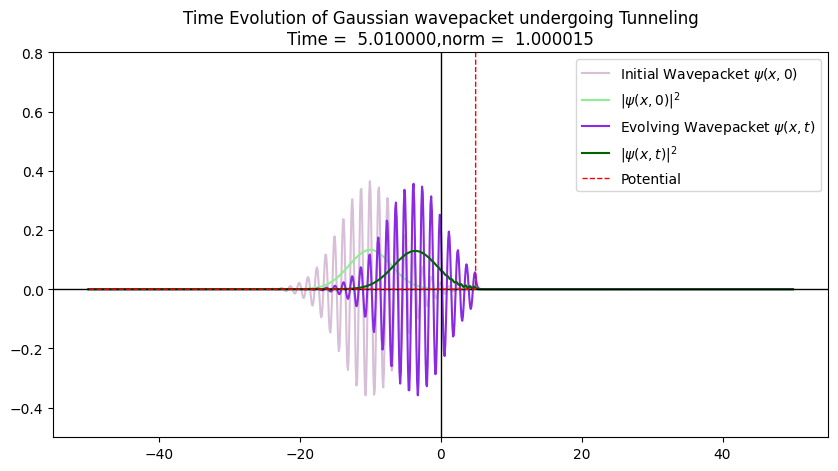

```
The final norm of the wavefunction is : 1.0000154218036335
The Norm is preserved
```

```python
import numpy as np
import matplotlib.pyplot as plt
from scipy.integrate import simpson

#Constants
sigma=3         #standard deviation of gaussian
x0=-10.0        #mean of gaussian
k=5.0           #This is the particle's initial energy : E=k**2/2

#Parameters
L=100           #length of the box
N=1000          #Discretized spatial points
dt=0.01         #Time step (Neumann Stability Condition)
t=0             #Initial time
tf=5            #Final time

#Initial condition
xs,dx=np.linspace(-L/2,L/2,N,retstep=True)
mu=dt/dx**2*(0.+1.j)/2

a=(np.sqrt(2*np.pi*sigma**2))
us=1/(np.sqrt(a))*np.exp(-(xs-x0)**2/(4*sigma**2)+1j*k*xs)    #This is same as the 1st column (initial time) of 2D array used in 1D diffusion equation. This 1D array will be updated with time

Norm_initial=simpson(np.abs(us)**2,x=xs)
print('The initial norm of the wavefunction is :',Norm_initial)

#Applied potential
Vs=np.where(xs[1:-1]<5,0,35)     #Only taking inside points which will be updated by M matrix. In NumPy, multiplying a 2D identity matrix by a 1D array broadcasts that array along the diagonal of the identity matrix.

#Seting Matrix
A1=np.eye(N-2)*(1-mu)+np.diag(-1j*dt/2*Vs)+mu/2*np.eye(N-2,k=1)+mu/2*np.eye(N-2,k=-1)
A2=np.eye(N-2)*(1+mu)+np.diag(1j*dt/2*Vs)-mu/2*np.eye(N-2,k=1)-mu/2*np.eye(N-2,k=-1)
B=np.dot(np.linalg.inv(A2),A1)

#Dynamic Plotting
plt.figure(figsize=(10,5))

plt.plot(xs,us,color='thistle',label=r'Initial Wavepacket $\psi(x,0)$')
plt.plot(xs,np.abs(us)**2,color='lightgreen',label=r'$|\psi(x,0)|^2$')

while t<tf:
    us[1:-1]=np.dot(B,us[1:-1])            #Solution matrix generated over space in a given time slice (except end points) which is being updated with next time slices
    t+=dt

plt.title('Time Evolution of Gaussian wavepacket undergoing Tunneling\n'+r'Time =%10.6f,norm =%10.6f'%(t,simpson(np.abs(us)**2,x=xs)))

plt.plot(xs,us,color='blueviolet',label=r'Evolving Wavepacket $\psi(x,t)$')
plt.plot(xs,np.abs(us)**2,color='darkgreen',label=r'$|\psi(x,t)|^2$')

plt.axvline(x=0,color='black',lw=1)
plt.axhline(y=0,color='black',lw=1)
plt.plot(xs[1:-1],Vs,'--',color='red',lw=1,label='Potential')

plt.ylim(-0.5,0.8)
plt.legend()
plt.show()

#Conservation of norm
Norm_final=simpson(np.abs(us)**2,x=xs)
print('The final norm of the wavefunction is :',Norm_final)

if round(Norm_initial/Norm_final)==1:
    print('The Norm is preserved')
else:
    print('Norm is not preserved')
```

# Solution of TDSE for a free gaussian wavepacket undergoing transmission through step potential barrier using FTCS Crank Nicolson Method

Taking average of 2nd order in space of both implicit and explicit method to preserve norm

```
>psi[x][t+1]=psi[x][t]+0.5*(i*dt/dx**2)*(psi[x+1][t]-2psi[x][t]+psi[x-1][t])-i*V[x][t]*dt*psi[x][t]

>psi[x][t+1]=mu*psi[x+1][t]+(1-2*mu-i*dt*V[x][t])*psi[x][t]+mu*psi[x-1][t]

>where mu=0.5*i*dt/dx**2
```

This algorithm preserves stability, accuracy and unitarity

```
The initial norm of the wavefunction is : 1.0000000000000002
```

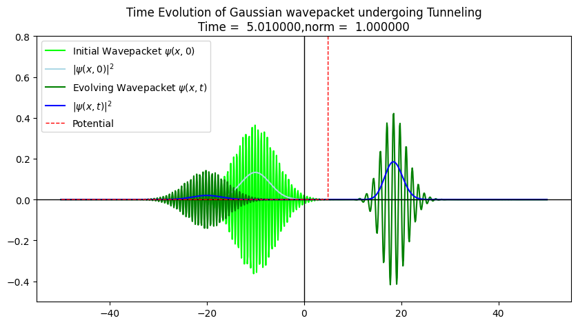

```
The final norm of the wavefunction is : 0.999999999999573
The Norm is preserved
```

```python
import numpy as np
import matplotlib.pyplot as plt
from scipy.integrate import simpson

#Constants
sigma=3         #standard deviation of gaussian
x0=-10.0        #mean of gaussian
k=10.0          #This is the particle's initial energy : E=k**2/2

#Parameters
L=100           #length of the box
N=1000          #Discretized spatial points
dt=0.01         #Time step (Neumann Stability Condition)
t=0             #Initial time
tf=5            #Final time

#Initial condition
xs,dx=np.linspace(-L/2,L/2,N,retstep=True)
mu=dt/dx**2*(0.+1.j)/2

a=(np.sqrt(2*np.pi*sigma**2))
us=1/(np.sqrt(a))*np.exp(-(xs-x0)**2/(4*sigma**2)+1j*k*xs)    #This is same as the 1st column (initial time) of 2D array used in 1D diffusion equation. This 1D array will be updated with time

Norm_initial=simpson(np.abs(us)**2,x=xs)
print('The initial norm of the wavefunction is :',Norm_initial)

#Applied potential
Vs=np.where(xs[1:-1]<5,0,35)     #Only taking inside points which will be updated by M matrix. In NumPy, multiplying a 2D identity matrix by a 1D array broadcasts that array along the diagonal of the identity matrix.

#Seting Matrix
A1=np.eye(N-2)*(1-mu)+np.diag(-1j*dt/2*Vs)+mu/2*np.eye(N-2,k=1)+mu/2*np.eye(N-2,k=-1)
A2=np.eye(N-2)*(1+mu)+np.diag(1j*dt/2*Vs)-mu/2*np.eye(N-2,k=1)-mu/2*np.eye(N-2,k=-1)
B=np.dot(np.linalg.inv(A2),A1)

#Dynamic Plotting
plt.figure(figsize=(10,5))

plt.plot(xs,us,color='lime',label=r'Initial Wavepacket $\psi(x,0)$')
plt.plot(xs,np.abs(us)**2,color='lightblue',label=r'$|\psi(x,0)|^2$')

while t<tf:
    us[1:-1]=np.dot(B,us[1:-1])            #Solution matrix generated over space in a given time slice (except end points) which is being updated with next time slices
    t+=dt

plt.title('Time Evolution of Gaussian wavepacket undergoing Tunneling\n'+r'Time =%10.6f,norm =%10.6f'%(t,simpson(np.abs(us)**2,x=xs)))

plt.plot(xs,us,color='green',label=r'Evolving Wavepacket $\psi(x,t)$')
plt.plot(xs,np.abs(us)**2,color='blue',label=r'$|\psi(x,t)|^2$')

plt.axvline(x=0,color='black',lw=1)
plt.axhline(y=0,color='black',lw=1)
plt.plot(xs[1:-1],Vs,'--',color='red',lw=1,label='Potential')

plt.ylim(-0.5,0.8)
plt.legend()
plt.show()

#Conservation of norm
Norm_final=simpson(np.abs(us)**2,x=xs)
print('The final norm of the wavefunction is :',Norm_final)

if round(Norm_initial/Norm_final)==1:
    print('The Norm is preserved')
else:
    print('Norm is not preserved')
```

# Solution of TDSE for a free gaussian wavepacket undergoing transmission through a finite width potential barrier using FTCS Crank Nicolson Method

Taking average of 2nd order in space of both implicit and explicit method to preserve norm

```
>psi[x][t+1]=psi[x][t]+0.5*(i*dt/dx**2)*(psi[x+1][t]-2psi[x][t]+psi[x-1][t])-i*V[x][t]*dt*psi[x][t]

>psi[x][t+1]=mu*psi[x+1][t]+(1-2*mu-i*dt*V[x][t])*psi[x][t]+mu*psi[x-1][t]

>where m=0.5*i*dt/dx**2
```

This algorithm preserves stability, accuracy and unitarity

```
The initial norm of the wavefunction is : 1.0000000000000002
```

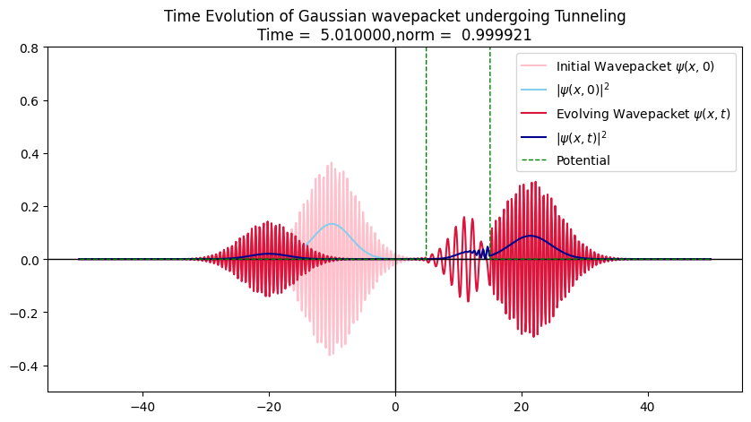

```
The final norm of the wavefunction is : 0.9999213900813576
The Norm is preserved
```

```python
import numpy as np
import matplotlib.pyplot as plt
from scipy.integrate import simpson

#Constants
sigma=3         #standard deviation of gaussian
x0=-10.0        #mean of gaussian
k=10.0          #This is the particle's initial energy : E=k**2/2

#Parameters
L=100           #length of the box
N=1000          #Discretized spatial points
dt=0.01         #Time step (Neumann Stability Condition)
t=0             #Initial time
tf=5            #Final time

#Initial condition
xs,dx=np.linspace(-L/2,L/2,N,retstep=True)
mu=dt/dx**2*(0.+1.j)/2

a=(np.sqrt(2*np.pi*sigma**2))
us=1/(np.sqrt(a))*np.exp(-(xs-x0)**2/(4*sigma**2)+1j*k*xs)    #This is same as the 1st column (initial time) of 2D array used in 1D diffusion equation. This 1D array will be updated with time

Norm_initial=simpson(np.abs(us)**2,x=xs)
print('The initial norm of the wavefunction is :',Norm_initial)

#Applied potential
Vs=np.where((xs[1:-1]>=5) & (xs[1:-1]<=15),35,0)     #Only taking inside points which will be updated by M matrix. In NumPy, multiplying a 2D identity matrix by a 1D array broadcasts that array along the diagonal of the identity matrix.

#Seting Matrix
A1=np.eye(N-2)*(1-mu)+np.diag(-1j*dt/2*Vs)+mu/2*np.eye(N-2,k=1)+mu/2*np.eye(N-2,k=-1)
A2=np.eye(N-2)*(1+mu)+np.diag(1j*dt/2*Vs)-mu/2*np.eye(N-2,k=1)-mu/2*np.eye(N-2,k=-1)
B=np.dot(np.linalg.inv(A2),A1)

#Dynamic Plotting
plt.figure(figsize=(10,5))

plt.plot(xs,us,color='pink',label=r'Initial Wavepacket $\psi(x,0)$')
plt.plot(xs,np.abs(us)**2,color='skyblue',label=r'$|\psi(x,0)|^2$')

while t<tf:
    us[1:-1]=np.dot(B,us[1:-1])            #Solution matrix generated over space in a given time slice (except end points) which is being updated with next time slices
    t+=dt

plt.title('Time Evolution of Gaussian wavepacket undergoing Tunneling\n'+r'Time =%10.6f,norm =%10.6f'%(t,simpson(np.abs(us)**2,x=xs)))


plt.plot(xs,us,color='crimson',label=r'Evolving Wavepacket $\psi(x,t)$')
plt.plot(xs,np.abs(us)**2,color='darkblue',label=r'$|\psi(x,t)|^2$')

plt.axvline(x=0,color='black',lw=1)
plt.axhline(y=0,color='black',lw=1)
plt.plot(xs[1:-1],Vs,'--',color='green',lw=1,label='Potential')

plt.ylim(-0.5,0.8)
plt.legend()
plt.show()

#Conservation of norm
Norm_final=simpson(np.abs(us)**2,x=xs)
print('The final norm of the wavefunction is :',Norm_final)

if round(Norm_initial/Norm_final)==1:
    print('The Norm is preserved')
else:
    print('Norm is not preserved')
```

# Solution of TDSE for a free gaussian wavepacket undergoing tunneling using FTCS Crank Nicolson Method

Taking average of 2nd order in space of both implicit and explicit method to preserve norm

```
>psi[x][t+1]=psi[x][t]+0.5*(i*dt/dx**2)*(psi[x+1][t]-2psi[x][t]+psi[x-1][t])-i*V[x][t]*dt*psi[x][t]

>psi[x][t+1]=mu*psi[x+1][t]+(1-2*mu-i*dt*V[x][t])*psi[x][t]+mu*psi[x-1][t]

>where mu=0.5*i*dt/dx**2
```

This algorithm preserves stability, accuracy and unitarity

```
The initial norm of the wavefunction is : 1.0000000000000002
```

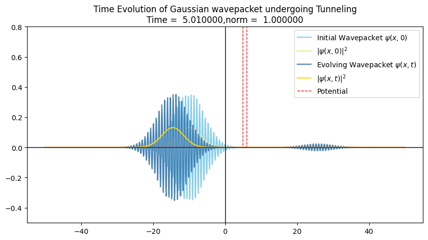

```
The final norm of the wavefunction is : 0.9999999999702724
The Norm is preserved
```

```python
import numpy as np
import matplotlib.pyplot as plt
from scipy.integrate import simpson

#Constants
sigma=3         #standard deviation of gaussian
x0=-10.0        #mean of gaussian
k=8.0           #This is the particle's initial energy : E=k**2/2

#Parameters
L=100           #length of the box
N=1000          #Discretized spatial points
dt=0.01         #Time step (Neumann Stability Condition)
t=0             #Initial time
tf=5            #Final time

#Initial condition
xs,dx=np.linspace(-L/2,L/2,N,retstep=True)
mu=dt/dx**2*(0.+1.j)/2

a=(np.sqrt(2*np.pi*sigma**2))
us=1/(np.sqrt(a))*np.exp(-(xs-x0)**2/(4*sigma**2)+1j*k*xs)    #This is same as the 1st column (initial time) of 2D array used in 1D diffusion equation. This 1D array will be updated with time

Norm_initial=simpson(np.abs(us)**2,x=xs)
print('The initial norm of the wavefunction is :',Norm_initial)

#Applied potential
Vs=np.where((xs[1:-1]>=5) & (xs[1:-1]<=6),35,0)     #Only taking inside points which will be updated by M matrix. In NumPy, multiplying a 2D identity matrix by a 1D array broadcasts that array along the diagonal of the identity matrix.

#Seting Matrix
A1=np.eye(N-2)*(1-mu)+np.diag(-1j*dt/2*Vs)+mu/2*np.eye(N-2,k=1)+mu/2*np.eye(N-2,k=-1)
A2=np.eye(N-2)*(1+mu)+np.diag(1j*dt/2*Vs)-mu/2*np.eye(N-2,k=1)-mu/2*np.eye(N-2,k=-1)
B=np.dot(np.linalg.inv(A2),A1)

#Dynamic Plotting
plt.figure(figsize=(10,5))

plt.plot(xs,us,color='skyblue',label=r'Initial Wavepacket $\psi(x,0)$')
plt.plot(xs,np.abs(us)**2,color='khaki',label=r'$|\psi(x,0)|^2$')

while t<tf:
    us[1:-1]=np.dot(B,us[1:-1])            #Solution matrix generated over space in a given time slice (except end points) which is being updated with next time slices
    t+=dt

plt.title('Time Evolution of Gaussian wavepacket undergoing Tunneling\n'+r'Time =%10.6f,norm =%10.6f'%(t,simpson(np.abs(us)**2,x=xs)))

plt.plot(xs,us,color='steelblue',label=r'Evolving Wavepacket $\psi(x,t)$')
plt.plot(xs,np.abs(us)**2,color='gold',label=r'$|\psi(x,t)|^2$')

plt.axvline(x=0,color='black',lw=1)
plt.axhline(y=0,color='black',lw=1)
plt.plot(xs[1:-1],Vs,'--',color='red',lw=1,label='Potential')

plt.ylim(-0.5,0.8)
plt.legend()
plt.show()

#Conservation of norm
Norm_final=simpson(np.abs(us)**2,x=xs)
print('The final norm of the wavefunction is :',Norm_final)

if round(Norm_initial/Norm_final)==1:
    print('The Norm is preserved')
else:
    print('Norm is not preserved')
```